# Data Camp Insights

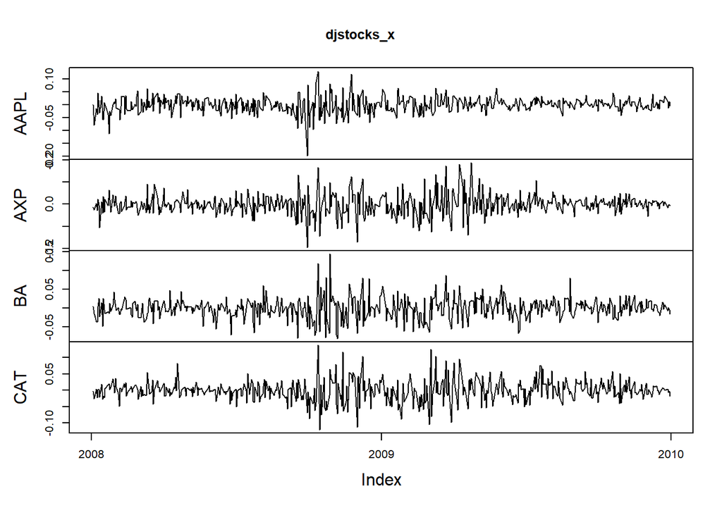

```r
# Plot djreturns
plot.zoo(djstocks_x)
```

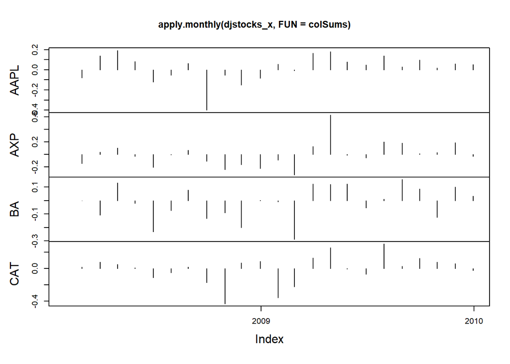

```r
# Plot monthly log-returns of djreturns
plot.zoo(apply.monthly(djstocks_x, FUN=colSums), type="h")
```

```r
data(GOLD, package='qrmdata')
data(OIL_Brent, package='qrmdata')

gold <- GOLD['1990/2015']
oil <- OIL_Brent['1990/2015']
str(gold)
```

```
## An 'xts' object on 1990-01-01/2015-12-31 containing:
##   Data: num [1:6784, 1] 399 399 395 396 405 ...
##  - attr(*, "dimnames")=List of 2
##   ..$ : NULL
##   ..$ : chr "GOLD"
##   Indexed by objects of class: [Date] TZ: UTC
##   xts Attributes:
##  NULL
```

```r
str(oil)
```

```
## An 'xts' object on 1990-01-02/2015-12-28 containing:
##   Data: num [1:6589, 1] 21.2 22.6 22.5 23.1 21.4 ...
##  - attr(*, "dimnames")=List of 2
##   ..$ : NULL
##   ..$ : chr "OIL_Brent"
##   Indexed by objects of class: [Date] TZ: UTC
##   xts Attributes:
##  NULL
```

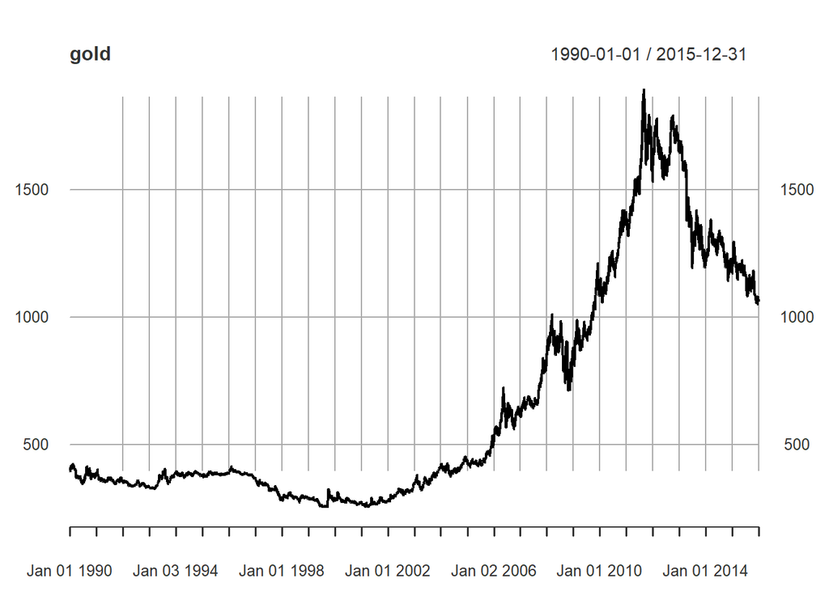

```r
par(mfrow=c(1, 1))
par(mfcol=c(1, 1))

# Plot gold and oil prices
plot(gold)
```

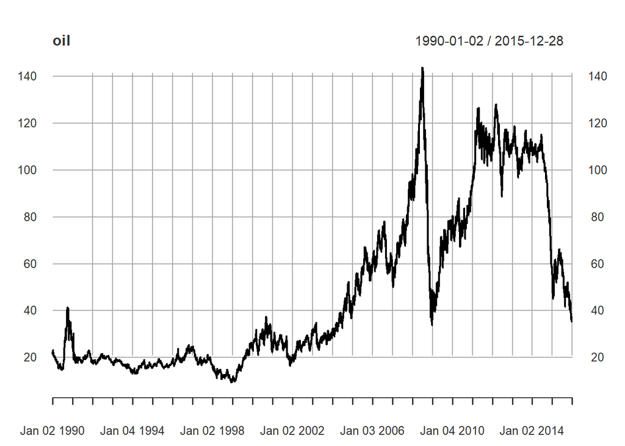

```r
plot(oil)
```

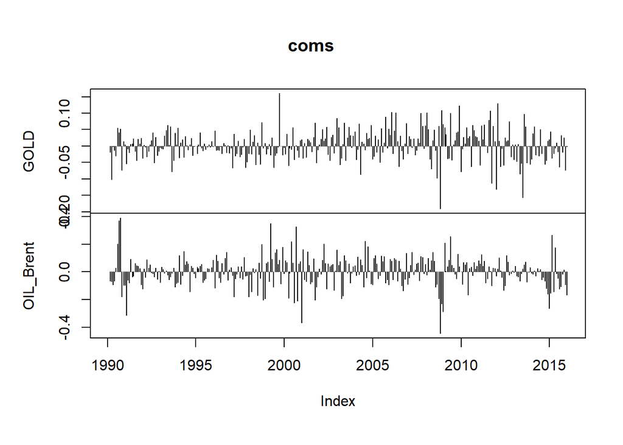

```r
# Calculate daily log-returns
goldx <- diff(log(gold))
oilx <- diff(log(oil))

# Calculate monthly log-returns
goldx_m <- apply.monthly(goldx, FUN=sum)
oilx_m <- apply.monthly(oilx, FUN=sum)

# Merge goldx_m and oilx_m into coms
coms <- merge(goldx_m, oilx_m)

# Plot coms with vertical bars
plot.zoo(coms, type="h")
```

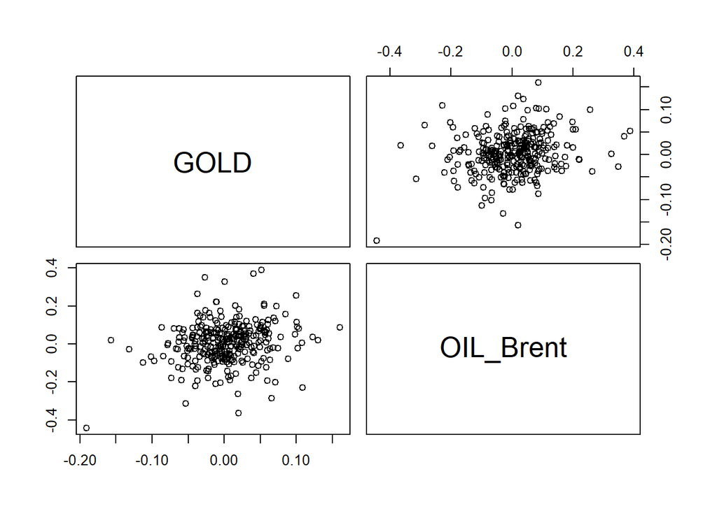

```r
# Make a pairwise scatterplot of coms
pairs(as.zoo(coms))
```

```r
data(ZCB_CAD, package="qrmdata")
zcb <- ZCB_CAD['2006/2015']
str(zcb)
```

```
## An 'xts' object on 2006-01-03/2015-08-31 containing:
##   Data: num [1:2411, 1:120] 3.47 3.44 3.42 3.45 3.46 ...
##  - attr(*, "dimnames")=List of 2
##   ..$ : NULL
##   ..$ : chr [1:120] "0.25y" "0.50y" "0.75y" "1.00y" ...
##   Indexed by objects of class: [Date] TZ: UTC
##   xts Attributes:
##  NULL
```

```r
# Identify and create vector containing column names for 1, 5, 10 year yields
names(zcb)
```

```
##   [1] "0.25y"  "0.50y"  "0.75y"  "1.00y"  "1.25y"  "1.50y"  "1.75y"  "2.00y"
##   [9] "2.25y"  "2.50y"  "2.75y"  "3.00y"  "3.25y"  "3.50y"  "3.75y"  "4.00y"
##  [17] "4.25y"  "4.50y"  "4.75y"  "5.00y"  "5.25y"  "5.50y"  "5.75y"  "6.00y"
##  [25] "6.25y"  "6.50y"  "6.75y"  "7.00y"  "7.25y"  "7.50y"  "7.75y"  "8.00y"
##  [33] "8.25y"  "8.50y"  "8.75y"  "9.00y"  "9.25y"  "9.50y"  "9.75y"  "10.00y"
##  [41] "10.25y" "10.50y" "10.75y" "11.00y" "11.25y" "11.50y" "11.75y" "12.00y"
##  [49] "12.25y" "12.50y" "12.75y" "13.00y" "13.25y" "13.50y" "13.75y" "14.00y"
##  [57] "14.25y" "14.50y" "14.75y" "15.00y" "15.25y" "15.50y" "15.75y" "16.00y"
##  [65] "16.25y" "16.50y" "16.75y" "17.00y" "17.25y" "17.50y" "17.75y" "18.00y"
##  [73] "18.25y" "18.50y" "18.75y" "19.00y" "19.25y" "19.50y" "19.75y" "20.00y"
##  [81] "20.25y" "20.50y" "20.75y" "21.00y" "21.25y" "21.50y" "21.75y" "22.00y"
##  [89] "22.25y" "22.50y" "22.75y" "23.00y" "23.25y" "23.50y" "23.75y" "24.00y"
##  [97] "24.25y" "24.50y" "24.75y" "25.00y" "25.25y" "25.50y" "25.75y" "26.00y"
## [105] "26.25y" "26.50y" "26.75y" "27.00y" "27.25y" "27.50y" "27.75y" "28.00y"
## [113] "28.25y" "28.50y" "28.75y" "29.00y" "29.25y" "29.50y" "29.75y" "30.00y"
```

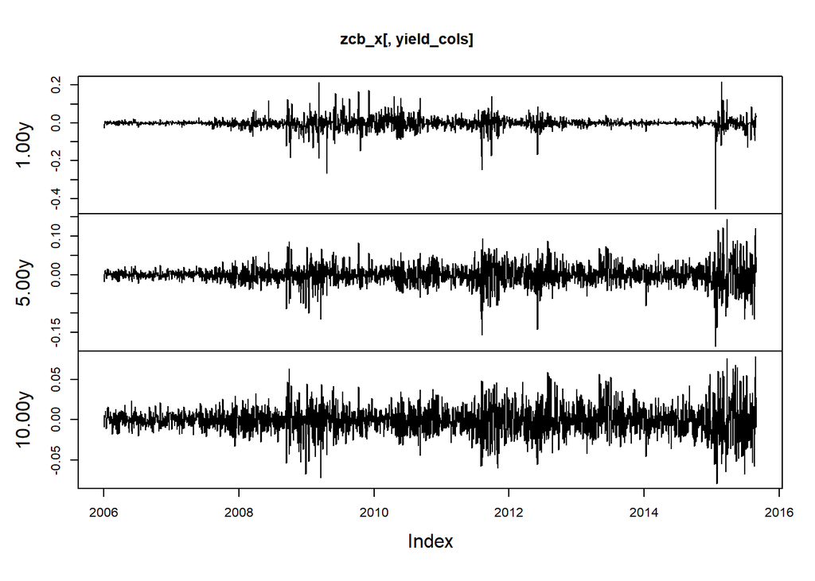

```r
yield_cols <- c("1.00y", "5.00y", "10.00y")

# Compute log-returns as zcb_x and plot them for same maturities
zcb_x <- diff(log(zcb))
plot.zoo(zcb_x[, yield_cols])
```

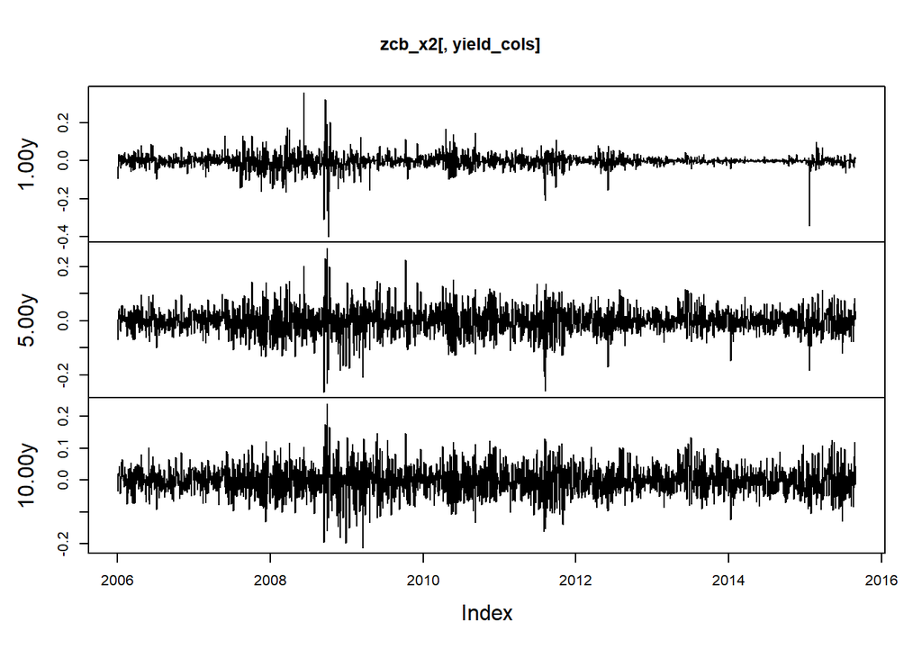

```r
# Compute simple returns as zcb_x2 and plot them for same maturities
zcb_x2 <- diff(zcb)
plot.zoo(zcb_x2[, yield_cols])
```

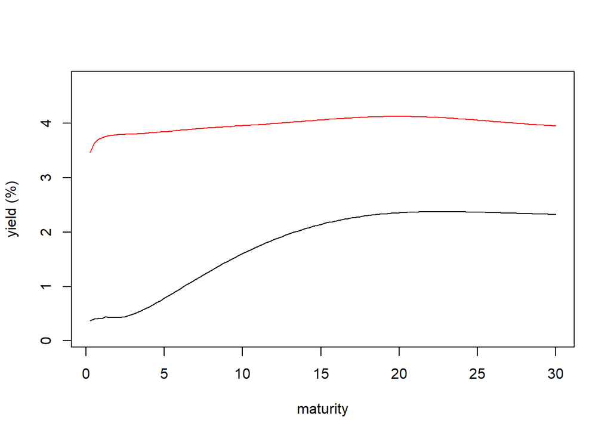

```r
# Make a vector containing the maturities
maturity <- (1:120)/4

# Plot the yield curve for the first day of zcb
plot(maturity, zcb[1, ], ylim = range(zcb), type = "l", ylab = "yield (%)", col = "red")

# Add a line for the last day of zcb
lines(maturity, zcb[nrow(zcb), ])
```

Chapter 2 - Real World Returns are Riskier than Normal

Normal distribution - if risk returns follow GBM, than log-returns would be normal:

- The normal distribution (bell curve) depends on a well known formula containing mu and sigma - N(mu, sigma-squared)
  - The sum of independent normal variables is itself normally dsitributed
- The Central Limit Theorem (CLT) says that the dsitribution of the sum of many iid trials will itself by normally dsitributed (even if the underlying iid distribution is decidedly non-normal)
- The “method of moments” is used to estimate the sample mean and the sample variance
  - The sigma-squared-hat with a mu subscript is the unbiased estimator (divide by n-1)
  - The sigma-squared-hat with no subscript is the maximum likelihood estimator (divide by n)

Testing for normality:

- The Q-Q test is a graphical test for normality, so the reference distribution is the standard normal
  - Q-Q plots can use other reference distributions
  - qqnorm(myData)
  - qqline(myData) # qqnorm should tend to fall along the line at all quantiles

Skewness, kurtosis, Jarque-Bera test:

- The Jarque-Bera test is based on skewness and kurtosis
  - The skewness (b) is the third moment, a measure of its asymmetry (b=0 for normal distribution) - moments::skewness()
  - The kurtosis (k) is the fourth moment, a measure of its heavy tails (k=3 for normal distribution) - moments::kurtosis()
- The Jarque-Bera test compares both skewness and kurtosis using a single test statistic, T
  - T = N/6 * (b**2 + 0.25*(k-3)**2) # uses a chi-squared with 2 degrees of freedom
  - moments::jarque.test(myData)
- Daily returns tend to be very non-normal, but the CLT suggests that the sum of these returns may become increasingly normal

Student t-distribution:

- The Student t-distribution has mu, sigma, and df and tends to be better for smaller data sets
  - With df at infinite, the student t-distribution becomes the normal distribution (df is also called nu) ; for nu less than 4, the kurtosis is infinite
  - The maximum likelihood method can be found using QRM::fit.st() - the $par.ests will have the parameters
- Due to some vagaries in how the dt() function is implemented in R, converting for a known mu, sigma, and nu
  - dt((myData - mu)/sigma, df=nu) / sigma

Example code includes:

```r
par(mfcol=c(1, 1))
par(mfrow=c(1, 1))

# Calculate average and standard deviation of djx
djx <- as.vector(diff(log(DJ['2008/2009'])))
djx <- sort(djx[2:length(djx)])
str(djx)
```

```
##  num [1:504] -0.082 -0.0801 -0.0762 -0.0723 -0.0586 ...
```

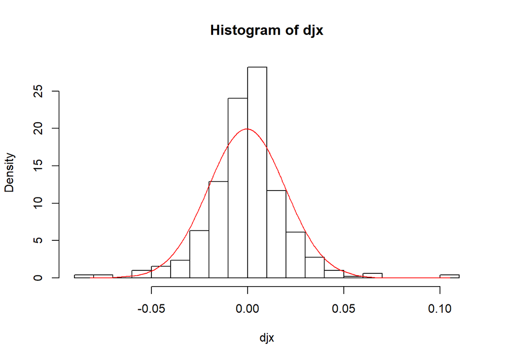

```r
mu <- mean(djx)
sigma <- sd(djx)

# Plot histogram of djx
hist(djx, nclass=20, probability=TRUE)

# Add the normal density as a red line to histogram
lines(djx, dnorm(djx, mean=mu, sd=sigma), col = "red")
```

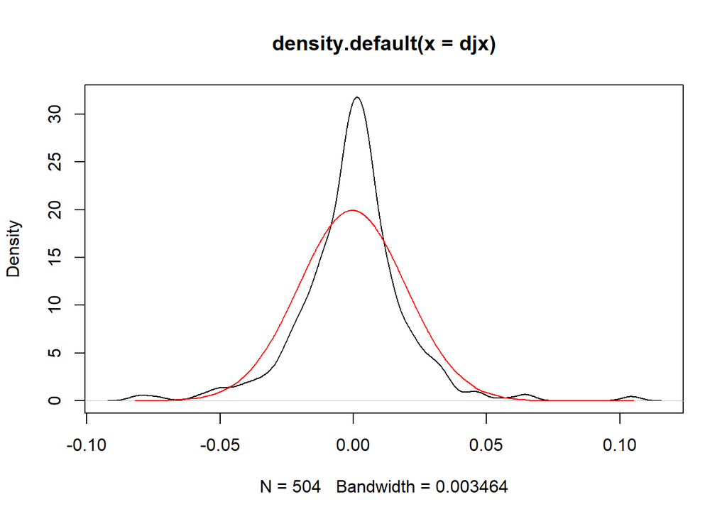

```r
# Plot non-parametric KDE of djx
plot(density(djx))

# Add the normal density as red line to KDE
lines(djx, dnorm(djx, mean=mu, sd=sigma), col = "red")
```

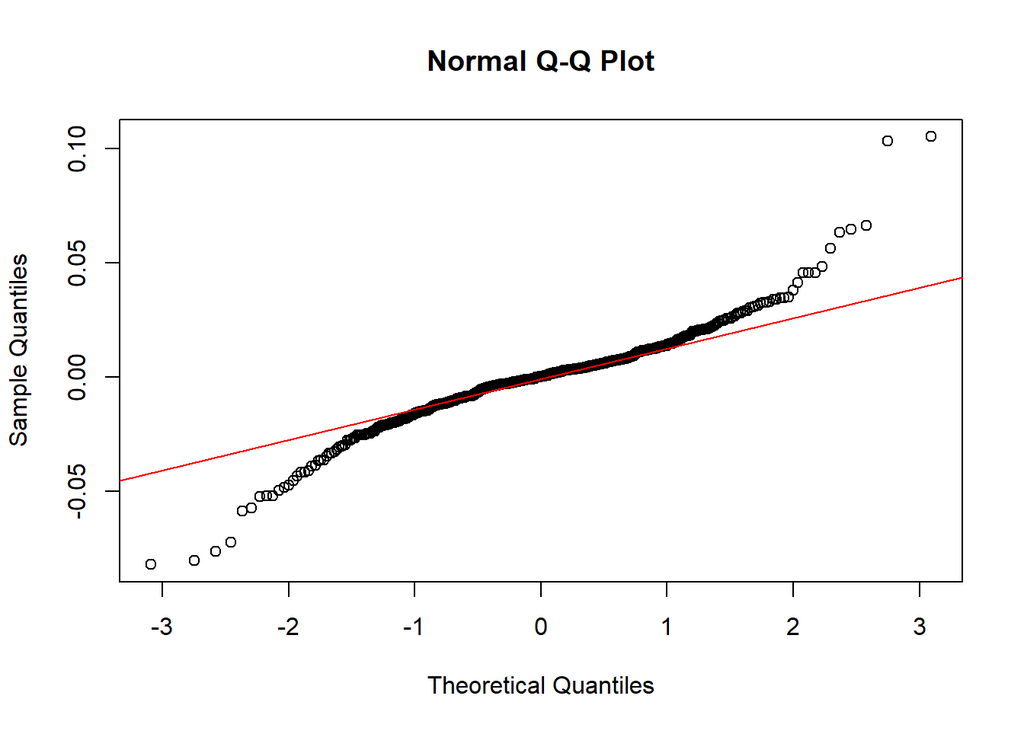

```r
# Make a Q-Q plot of djx and add a red line
qqnorm(djx)
qqline(djx, col="red")
```

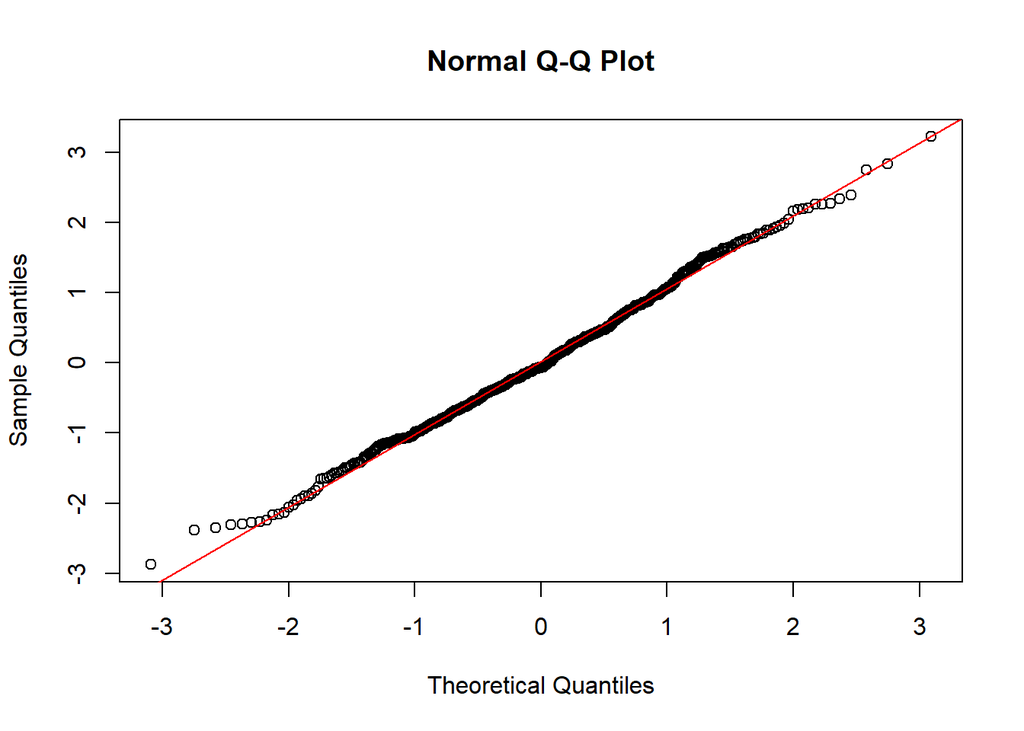

```r
# Calculate the length of djx as n
n <- length(djx)

# Generate n standard normal variables, make a Q-Q plot, add a red line
x1 <- rnorm(n)
qqnorm(x1)
qqline(x1, col="red")
```

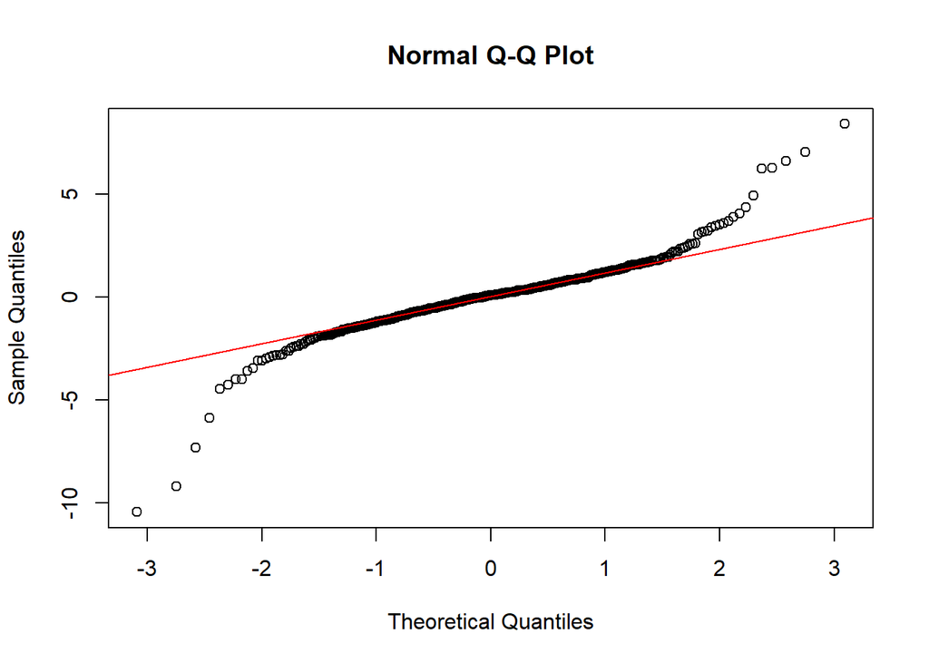

```r
# Generate n Student t variables, make a Q-Q plot, add a red line
x2 <- rt(n, df = 4)
qqnorm(x2)
qqline(x2, col="red")
```

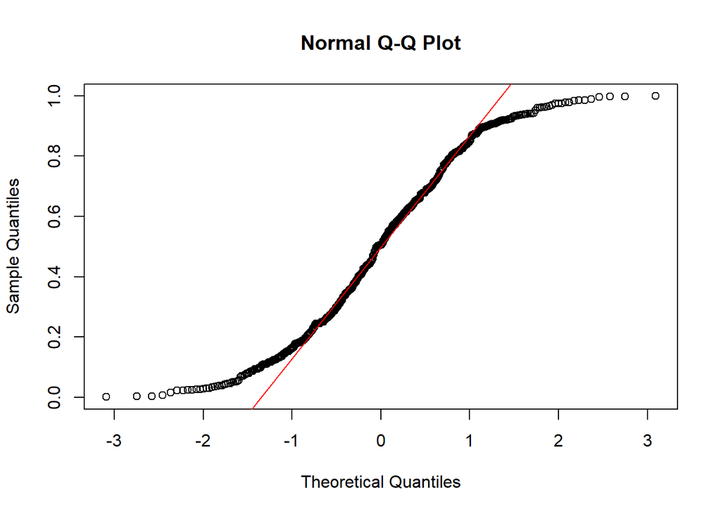

```r
# Generate n standard uniform variables, make a Q-Q plot, add red line
x3 <- runif(n)
qqnorm(x3)
qqline(x3, col="red")
```

```r
dj0811 <- DJ_const["2008/2011"]
djreturns <- diff(log(dj0811))[2:nrow(dj0811), !(names(dj0811) %in% c("V"))]
str(djreturns)
```

```
## An 'xts' object on 2008-01-03/2011-12-30 containing:
##   Data: num [1:1008, 1:29] 0.000462 -0.079406 -0.013476 -0.036635 0.046494 ...
##  - attr(*, "dimnames")=List of 2
##   ..$ : NULL
##   ..$ : chr [1:29] "AAPL" "AXP" "BA" "CAT" ...
##   Indexed by objects of class: [Date] TZ: UTC
##   xts Attributes:
## List of 2
##  $ src    : chr "yahoo"
##  $ updated: POSIXct[1:1], format: "2016-01-02 20:51:40"
```

```r
# Calculate average and standard deviation of djx
djx <- as.vector(diff(log(DJ['2008/2011'])))
djx <- sort(djx[2:length(djx)])
str(djx)
```

```
##  num [1:1008] -0.082 -0.0801 -0.0762 -0.0723 -0.0586 ...
```

```r
# Calculate skewness and kurtosis of djx
moments::skewness(djx)
```

```
## [1] 0.001913285
```

```r
moments::kurtosis(djx)
```

```
## [1] 9.058875
```

```r
# Carry out a Jarque-Bera test for djx
moments::jarque.test(djx)
```

```
##
##  Jarque-Bera Normality Test
##
## data:  djx
## JB = 1541.8, p-value < 2.2e-16
## alternative hypothesis: greater
```

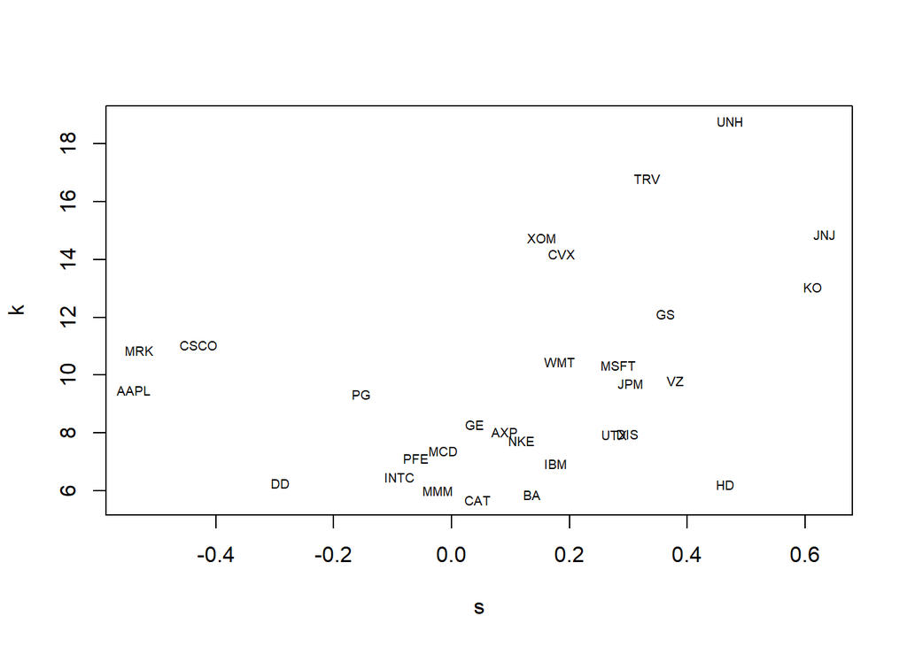

```r
# Calculate skewness and kurtosis of djreturns
s <- apply(djreturns, 2, FUN=moments::skewness)
k <- apply(djreturns, 2, FUN=moments::kurtosis)

# Plot k against s and add text labels to identify stocks
plot(s, k, type="n")
text(s, k, names(s), cex = 0.6)
```

```r
# Carry out Jarque-Bera tests for each constituent in djreturns
apply(djreturns, 2, FUN=moments::jarque.test)
```

```
## $AAPL
##
##  Jarque-Bera Normality Test
##
## data:  newX[, i]
## JB = 1819.5, p-value < 2.2e-16
## alternative hypothesis: greater
##
##
## $AXP
##
##  Jarque-Bera Normality Test
##
## data:  newX[, i]
## JB = 1066.1, p-value < 2.2e-16
## alternative hypothesis: greater
##
##
## $BA
##
##  Jarque-Bera Normality Test
##
## data:  newX[, i]
## JB = 347.08, p-value < 2.2e-16
## alternative hypothesis: greater
##
##
## $CAT
##
##  Jarque-Bera Normality Test
##
## data:  newX[, i]
## JB = 304.64, p-value < 2.2e-16
## alternative hypothesis: greater
##
##
## $CSCO
##
##  Jarque-Bera Normality Test
##
```

[output cut: 204 more lines]

```
##
##  Jarque-Bera Normality Test
##
## data:  newX[, i]
## JB = 2350.8, p-value < 2.2e-16
## alternative hypothesis: greater
##
##
## $XOM
##
##  Jarque-Bera Normality Test
##
## data:  newX[, i]
## JB = 5812.4, p-value < 2.2e-16
## alternative hypothesis: greater
```

```r
dj0015 <- DJ_const["2000/2015"]
djx_d <- diff(log(dj0015))[2:nrow(dj0015), !(names(dj0015) %in% c("V"))]
str(djx_d)
```

```
## An 'xts' object on 2000-01-04/2015-12-31 containing:
##   Data: num [1:4024, 1:29] -0.0881 0.0145 -0.0905 0.0463 -0.0177 ...
##  - attr(*, "dimnames")=List of 2
##   ..$ : NULL
##   ..$ : chr [1:29] "AAPL" "AXP" "BA" "CAT" ...
##   Indexed by objects of class: [Date] TZ: UTC
##   xts Attributes:
## List of 2
##  $ src    : chr "yahoo"
##  $ updated: POSIXct[1:1], format: "2016-01-02 20:51:40"
```

```r
# Calculate weekly and monthly log-returns from djx_d
djx_w <- apply.weekly(djx_d, FUN=colSums)
djx_m <- apply.monthly(djx_d, FUN=colSums)

# Calculate the p-value for each series in djx_d
apply(djx_d, 2, function(v){moments::jarque.test(v)$p.value})
```

```
## AAPL  AXP   BA  CAT CSCO  CVX   DD  DIS   GE   GS   HD  IBM INTC  JNJ  JPM   KO
##    0    0    0    0    0    0    0    0    0    0    0    0    0    0    0    0
##  MCD  MMM  MRK MSFT  NKE  PFE   PG  TRV  UNH  UTX   VZ  WMT  XOM
##    0    0    0    0    0    0    0    0    0    0    0    0    0
```

```r
# Calculate the p-value for each series in djx_w
apply(djx_w, 2, function(v){moments::jarque.test(v)$p.value})
```

```
## AAPL  AXP   BA  CAT CSCO  CVX   DD  DIS   GE   GS   HD  IBM INTC  JNJ  JPM   KO
##    0    0    0    0    0    0    0    0    0    0    0    0    0    0    0    0
##  MCD  MMM  MRK MSFT  NKE  PFE   PG  TRV  UNH  UTX   VZ  WMT  XOM
##    0    0    0    0    0    0    0    0    0    0    0    0    0
```

```r
# Calculate the p-value for each series in djx_m
apply(djx_m, 2, function(v){moments::jarque.test(v)$p.value})
```

```
##         AAPL          AXP           BA          CAT         CSCO          CVX
## 0.000000e+00 0.000000e+00 0.000000e+00 0.000000e+00 1.110223e-16 1.677566e-01
##           DD          DIS           GE           GS           HD          IBM
## 5.059611e-03 4.043754e-11 3.086420e-13 3.259324e-02 5.493080e-02 0.000000e+00
##         INTC          JNJ          JPM           KO          MCD          MMM
## 0.000000e+00 5.472560e-08 1.982609e-06 5.641173e-07 0.000000e+00 9.341348e-02
##          MRK         MSFT          NKE          PFE           PG          TRV
## 1.524618e-07 0.000000e+00 0.000000e+00 3.076613e-01 0.000000e+00 0.000000e+00
##          UNH          UTX           VZ          WMT          XOM
## 0.000000e+00 0.000000e+00 0.000000e+00 7.281104e-04 1.100037e-02
```

```r
# Calculate average and standard deviation of djx
djx <- diff(log(DJ))['2008/2011']
str(djx)
```

```
## An 'xts' object on 2008-01-02/2011-12-30 containing:
##   Data: num [1:1009, 1] -0.01679 0.000978 -0.019844 0.002131 -0.018762 ...
##  - attr(*, "dimnames")=List of 2
##   ..$ : NULL
##   ..$ : chr "^DJI"
##   Indexed by objects of class: [Date] TZ: UTC
##   xts Attributes:
## List of 2
##  $ src    : chr "yahoo"
##  $ updated: POSIXct[1:1], format: "2016-01-02 20:42:12"
```

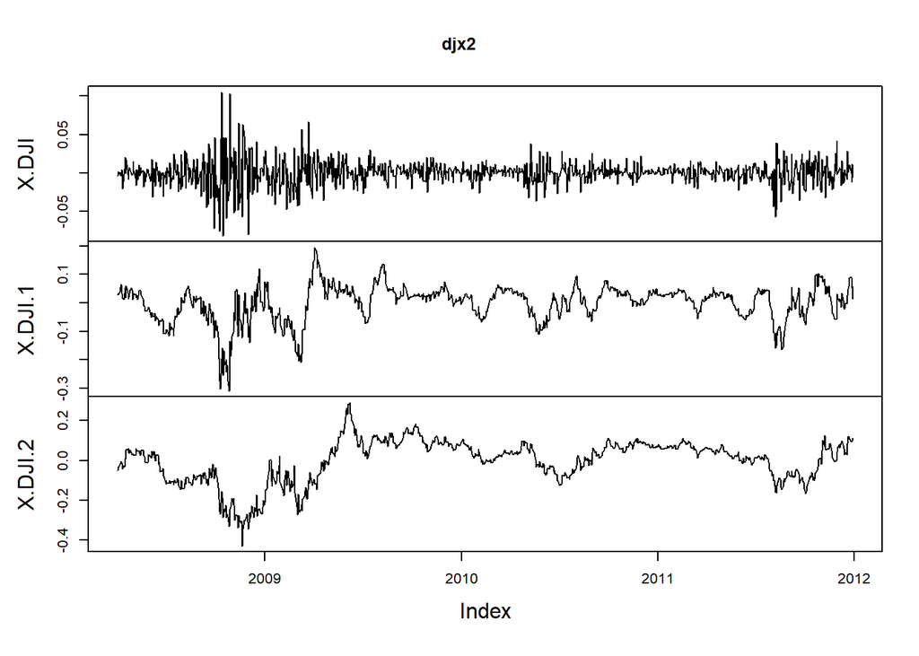

```r
# When you aggregate series by summing daily log-returns into longer intervals, you analyze a smaller amount of observations
# To preserve the quantity of data, you can calculate overlapping returns with the rollapplyr() function; this also creates strong correlations between observations

# There are 5 trading days in the average calendar week
# By computing the 5-day moving sums of the log-returns of daily index data, you obtain approximate overlapping weekly returns ending on each calendar week
# Similarly, calculating 21-day moving sums gives approximate overlapping monthly returns, and calculating 63-day moving sums gives approximate overlapping quarterly returns

# Calculate a 21-day moving sum of djx
djx21 <- rollapplyr(djx, width=21, FUN=sum)[-(1:20)]

# Calculate a 63-day moving sum of djx
djx63 <- rollapplyr(djx, width=63, FUN=sum)[-(1:62)]

# Merge the three series and plot
djx2 <- merge(djx, djx21, djx63, all=FALSE)
plot.zoo(djx2)
```

```r
# Compute the skewness and kurtosis for each series in djx2
apply(djx2, 2, FUN=moments::skewness)
```

```
##       X.DJI     X.DJI.1     X.DJI.2
## -0.01210181 -1.16175436 -0.87397911
```

```r
apply(djx2, 2, FUN=moments::kurtosis)
```

```
##    X.DJI  X.DJI.1  X.DJI.2
## 9.273714 5.851229 3.845981
```

```r
# Conduct the Jarque-Bera test to each series in djx2
apply(djx2, 2, FUN=moments::jarque.test)
```

```
## $X.DJI
##
##  Jarque-Bera Normality Test
##
## data:  newX[, i]
## JB = 1553.1, p-value < 2.2e-16
## alternative hypothesis: greater
##
##
## $X.DJI.1
##
##  Jarque-Bera Normality Test
##
## data:  newX[, i]
## JB = 533.8, p-value < 2.2e-16
## alternative hypothesis: greater
##
##
## $X.DJI.2
##
##  Jarque-Bera Normality Test
##
## data:  newX[, i]
## JB = 148.8, p-value < 2.2e-16
## alternative hypothesis: greater
```

```r
djx <- sort(as.vector(djx))
str(djx)
```

```
##  num [1:1009] -0.082 -0.0801 -0.0762 -0.0723 -0.0586 ...
```

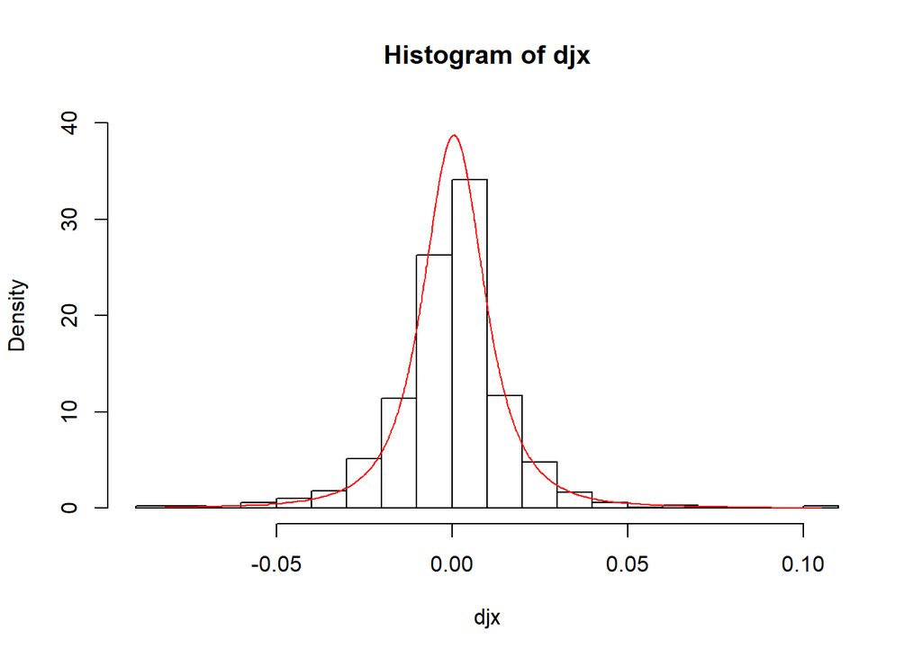

```r
# Fit a Student t distribution to djx
tfit <- QRM::fit.st(djx)

# Define tpars, nu, mu, and sigma
tpars <- tfit$par.ests
nu <- tpars["nu"]
mu <- tpars["mu"]
sigma <- tpars["sigma"]

# Plot a histogram of djx
hist(djx, nclass = 20, probability = TRUE, ylim = range(0, 40))

# Compute the fitted t density at the values djx
yvals <- dt((djx - mu)/sigma, df = nu)/sigma

# Superimpose a red line to show the fitted t density
lines(djx, yvals, col = "red")
```

```r
data(JPY_USD, package="qrmdata")
USD_JPY <- 1/JPY_USD
fx_d <- diff(log(merge(GBP_USD, EUR_USD, USD_JPY, all = TRUE)))['2001/2015']
str(fx_d)
```

```
## An 'xts' object on 2001-01-01/2015-12-31 containing:
##   Data: num [1:5478, 1:3] 0.001673 0.003004 -0.006689 0.007755 0.000399 ...
##  - attr(*, "dimnames")=List of 2
##   ..$ : NULL
##   ..$ : chr [1:3] "GBP.USD" "EUR.USD" "JPY.USD"
##   Indexed by objects of class: [Date] TZ: UTC
##   xts Attributes:
## List of 2
##  $ src    : chr "oanda"
##  $ updated: POSIXct[1:1], format: "2016-01-02 20:55:00"
```

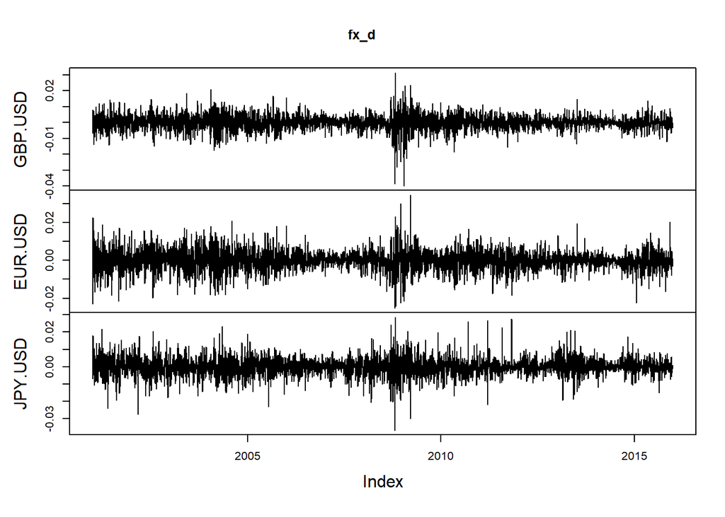

```r
# Plot the daily log-return series in fx_d
plot.zoo(fx_d)
```

```r
# Apply the Jarque-Bera test to each of the series in fx_d
apply(fx_d, 2, FUN=moments::jarque.test)
```

```
## $GBP.USD
##
##  Jarque-Bera Normality Test
##
## data:  newX[, i]
## JB = 10969, p-value < 2.2e-16
## alternative hypothesis: greater
##
##
## $EUR.USD
##
##  Jarque-Bera Normality Test
##
## data:  newX[, i]
## JB = 2793.5, p-value < 2.2e-16
## alternative hypothesis: greater
##
##
## $JPY.USD
##
##  Jarque-Bera Normality Test
##
## data:  newX[, i]
## JB = 5043.6, p-value < 2.2e-16
## alternative hypothesis: greater
```

```r
fx_m <- apply.monthly(fx_d, FUN=colSums)
str(fx_m)
```

```
## An 'xts' object on 2001-01-31/2015-12-31 containing:
##   Data: num [1:180, 1:3] -0.01948 -0.01334 -0.01978 0.01011 -0.00934 ...
##  - attr(*, "dimnames")=List of 2
##   ..$ : NULL
##   ..$ : chr [1:3] "GBP.USD" "EUR.USD" "JPY.USD"
##   Indexed by objects of class: [POSIXct,POSIXt] TZ: UTC
##   xts Attributes:
## List of 2
##  $ src    : chr "oanda"
##  $ updated: POSIXct[1:1], format: "2016-01-02 20:55:00"
```

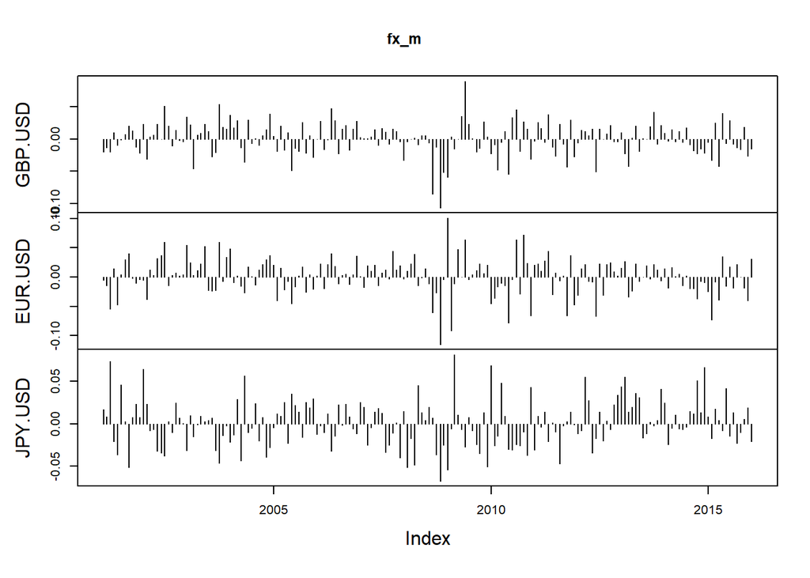

```r
# Plot the monthly log-return series in fx_m
plot.zoo(fx_m, type="h")
```

```r
# Apply the Jarque-Bera test to each of the series in fx_m
apply(fx_m, 2, FUN=moments::jarque.test)
```

```
## $GBP.USD
##
##  Jarque-Bera Normality Test
##
## data:  newX[, i]
## JB = 41.032, p-value = 1.23e-09
## alternative hypothesis: greater
##
##
## $EUR.USD
##
##  Jarque-Bera Normality Test
##
## data:  newX[, i]
## JB = 22.72, p-value = 1.165e-05
## alternative hypothesis: greater
##
##
## $JPY.USD
##
##  Jarque-Bera Normality Test
##
## data:  newX[, i]
## JB = 3.6547, p-value = 0.1608
## alternative hypothesis: greater
```

```r
# Fit a Student t distribution to each of the series in fx_m
apply(fx_m, 2, function(v){QRM::fit.st(v)$par.ests})
```

```
##            GBP.USD     EUR.USD      JPY.USD
## nu    6.0444926549 4.912878245 1.843235e+01
## mu    0.0008655583 0.001947311 1.068786e-04
## sigma 0.0204357969 0.023764956 2.553037e-02
```

```r
zcbx_m <- apply.monthly(zcb_x['2006/2015', c("1.00y", "5.00y", "10.00y")], 2, FUN=colSums)
str(zcbx_m)
```

```
## An 'xts' object on 2006-01-31/2015-08-31 containing:
##   Data: num [1:116, 1:3] 0.00361 0.03731 0.01586 0.02744 0.02429 ...
##  - attr(*, "dimnames")=List of 2
##   ..$ : NULL
##   ..$ : chr [1:3] "1.00y" "5.00y" "10.00y"
##   Indexed by objects of class: [POSIXct,POSIXt] TZ: UTC
##   xts Attributes:
##  NULL
```

```r
zcb_x2 <- 100 * diff(zcb)
zcbx2_m <- apply.monthly(zcb_x2['2006/2015', c("1.00y", "5.00y", "10.00y")], 2, FUN=colSums)
str(zcbx2_m)
```

```
## An 'xts' object on 2006-01-31/2015-08-31 containing:
##   Data: num [1:116, 1:3] 1.35 14.26 6.22 11.01 10 ...
##  - attr(*, "dimnames")=List of 2
##   ..$ : NULL
##   ..$ : chr [1:3] "1.00y" "5.00y" "10.00y"
##   Indexed by objects of class: [POSIXct,POSIXt] TZ: UTC
##   xts Attributes:
##  NULL
```

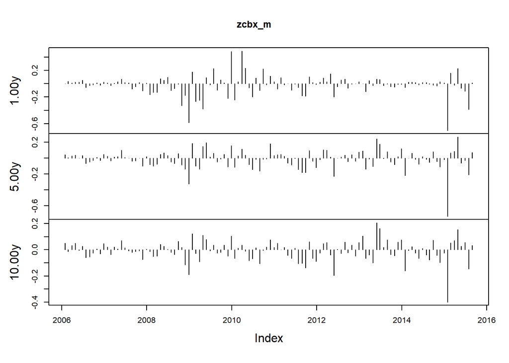

```r
# Plot the interest-rate return series zcbx_m and zcbx2_m
plot.zoo(zcbx_m, type="h")
```

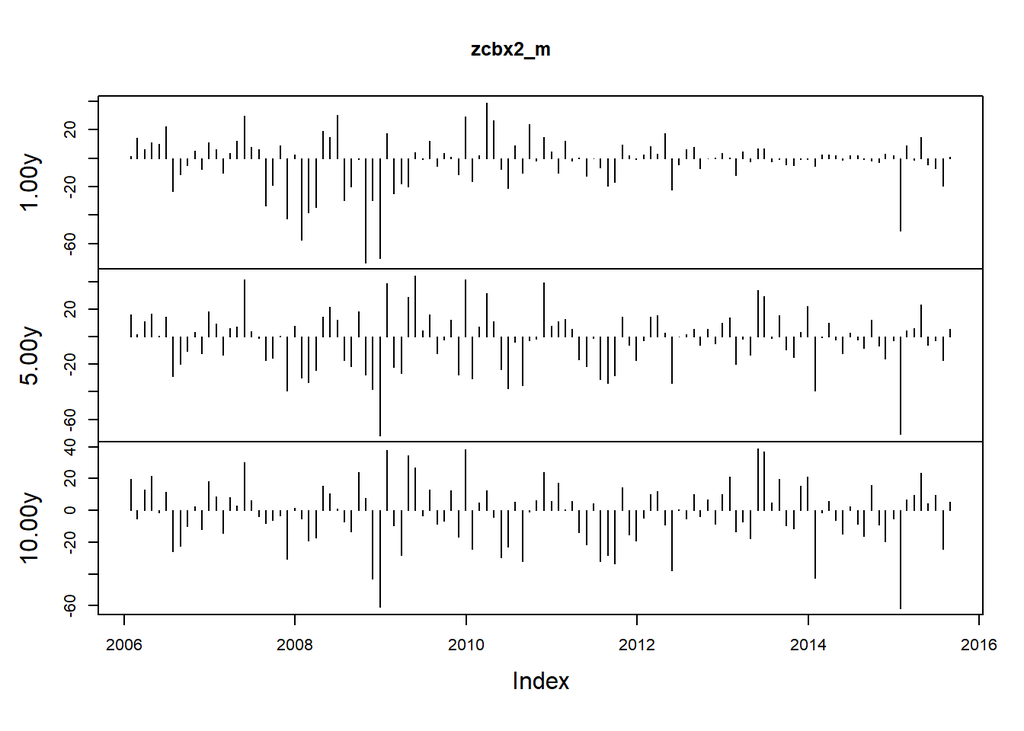

```r
plot.zoo(zcbx2_m, type="h")
```

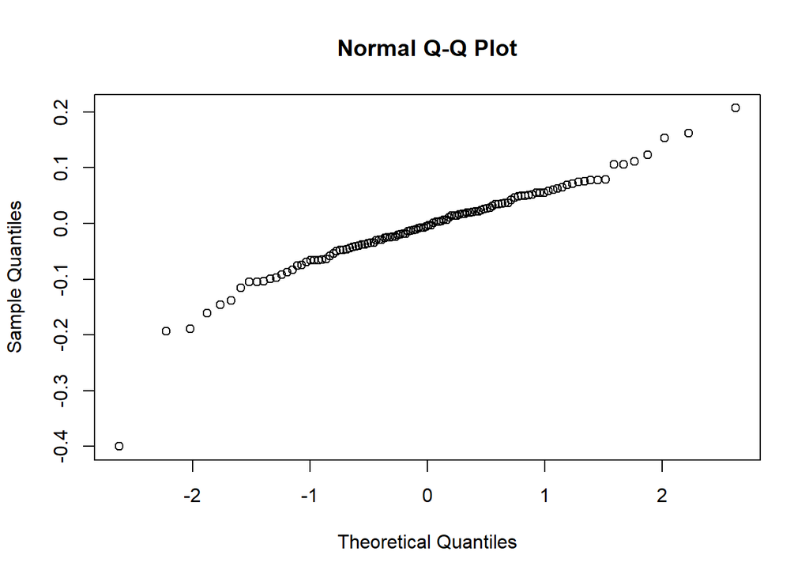

```r
# Make Q-Q plots of the 3rd component series of zcbx_m and zcbx2_m
qqnorm(zcbx_m[, 3])
```

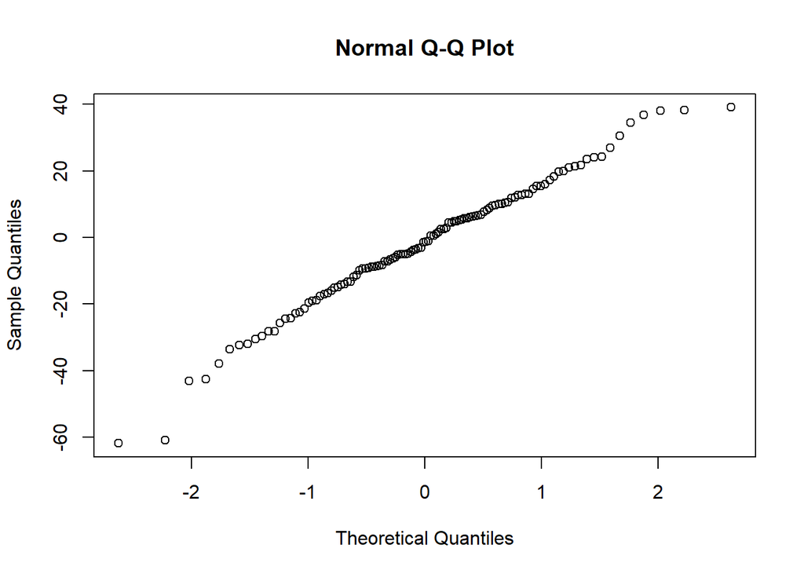

```r
qqnorm(zcbx2_m[, 3])
```

```r
# Compute the kurtosis of each series in zcbx_m and zcbx2_m
apply(zcbx_m, 2, FUN=moments::kurtosis)
```

```
##     1.00y     5.00y    10.00y
##  8.597562 13.891654  7.991542
```

```r
apply(zcbx2_m, 2, FUN=moments::kurtosis)
```

```
##    1.00y    5.00y   10.00y
## 6.107231 3.728619 3.511835
```

```r
# Conduct the Jarque-Bera test on each series in zcbx_m and zcbx2_m
apply(zcbx_m, 2, FUN=moments::jarque.test)
```

```
## $`1.00y`
##
##  Jarque-Bera Normality Test
##
## data:  newX[, i]
## JB = 164.96, p-value < 2.2e-16
## alternative hypothesis: greater
##
##
## $`5.00y`
##
##  Jarque-Bera Normality Test
##
## data:  newX[, i]
## JB = 644.21, p-value < 2.2e-16
## alternative hypothesis: greater
##
##
## $`10.00y`
##
##  Jarque-Bera Normality Test
##
## data:  newX[, i]
## JB = 142.27, p-value < 2.2e-16
## alternative hypothesis: greater
```

```r
apply(zcbx2_m, 2, FUN=moments::jarque.test)
```

```
## $`1.00y`
##
##  Jarque-Bera Normality Test
##
## data:  newX[, i]
## JB = 77.596, p-value < 2.2e-16
## alternative hypothesis: greater
##
##
## $`5.00y`
##
##  Jarque-Bera Normality Test
##
## data:  newX[, i]
## JB = 5.7135, p-value = 0.05746
## alternative hypothesis: greater
##
##
## $`10.00y`
##
##  Jarque-Bera Normality Test
##
## data:  newX[, i]
## JB = 4.0954, p-value = 0.129
## alternative hypothesis: greater
```

Chapter 3 - Real World Returns are Volatile and Correlated

Characteristics of volatile return series:

- Investigation of whether financial returns can be modeled as iid - “random walk model” (implication that past prices cannot be used to predict future behavior)
- Can compare real returns with iid data derived from either normal distributions or t-distributions
  - Clear differences between real data and modeled data - real data have “volatility clustering”
  - The “volatility clustering” is valuable for risk management as well as for prediction of future volatility

Estimating serial correlations:

- With serial dependencies, existing volatility is suggestive of continued volatility
  - The sample acf with lag k can help to estimate the behavior – denoted as rho-hat(k)
  - The sample acf assumes that the series has the property of stationarity
- The sample acf plot (coorelogram) gives the acf for various lags of k - blue dashed lines are 95% confidence bounds for the correlation estimates
  - Note that k=0 will trivially have correlation of 1
  - acf(abs(x)) may reveal things that are not shown by acf(x) - sign changes can hide the serial dependencies

The Ljung-Box test - numerical test of squared sample autocorrelations up to a value of k-lags:

- When including k lags, the value of the test statistic is compared with the chi-squared distribution of the same degree of freedom
  - Should be carried out on either the returns or the abosolute value of the returns (which are often where the volatility are clustered)
  - Box.test(myData, lag=, type=“Ljung”) # the type=“Ljung” gets Box-Ljung while the type=“Box” gets the Pierce test
- Generally, the closer the data get to normal (e.g., quarterly or monthly or perhaps weekly rather than daily), the significance of the Box-Ljung test will go away

Looking at extremes in volatile return series:

- Can be interesting just to look at days with extreme returns - for example, where the log-returns are less than -0.025
  - Tend to be clusters of extreme values on these dimensions around the times of large stock market changes - very different behavior from iid

Stylised facts of return series:

- Properties observed in equities are broadly consistent across other asset classes - commonly called the “stylized facts”
  - Return series tend to be heavier-tailed than normal distributions (leptokurtic)
  - Volatility of return series appears to vary over time
  - Return series tend to show very little serial correlation
  - Absolute values of return series tend to show protfound serial correlation
  - Extreme returns appear in clusters
  - Returns aggregated over longer time periods tend to become more normally distributed and less serially dependent

Example code includes:

```r
djx <- diff(log(DJ))['2008/2011']
str(djx)
```

```
## An 'xts' object on 2008-01-02/2011-12-30 containing:
##   Data: num [1:1009, 1] -0.01679 0.000978 -0.019844 0.002131 -0.018762 ...
##  - attr(*, "dimnames")=List of 2
##   ..$ : NULL
##   ..$ : chr "^DJI"
##   Indexed by objects of class: [Date] TZ: UTC
##   xts Attributes:
## List of 2
##  $ src    : chr "yahoo"
##  $ updated: POSIXct[1:1], format: "2016-01-02 20:42:12"
```

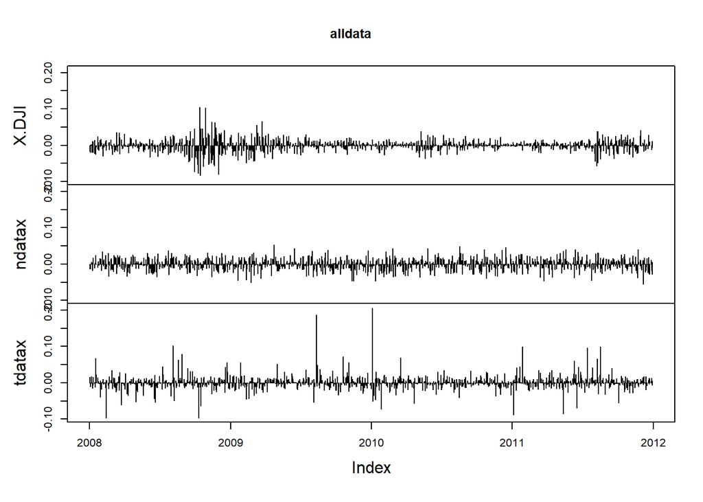

```r
npars <- c(mu=-8.150765e-05, sigma=1.643593e-02)

# Compute the length n of djx
n <- length(djx)

#  Generate a normal sample of size n with parameters given by npars
ndata <- rnorm(n)*npars[2] + npars[1]

# Generate a t-distributed sample of size n with paramaters given by tpars
tdata <- rt(n, df = tpars[1])*tpars[3] + tpars[2]

# Make ndata and tdata into xts objects
ndatax <- xts(ndata, time(djx))
tdatax <- xts(tdata, time(djx))

# Merge djx, ndatax, and tdatax and plot
alldata <- merge(djx, ndatax, tdatax)
plot.zoo(alldata, type="h", ylim = range(alldata))
```

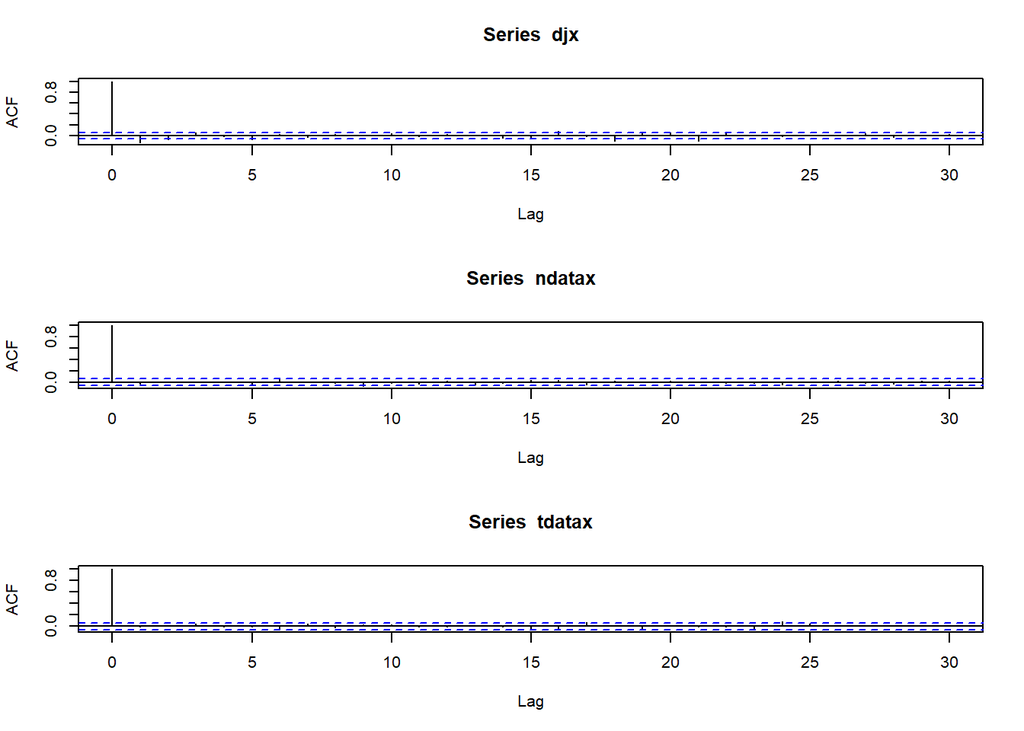

```r
# Set up a plot region to show 3 plots at a time
par(mfrow = c(3, 1))

# Plot the acfs of djx, ndata and tdata
acf(djx)
acf(ndatax)
acf(tdatax)
```

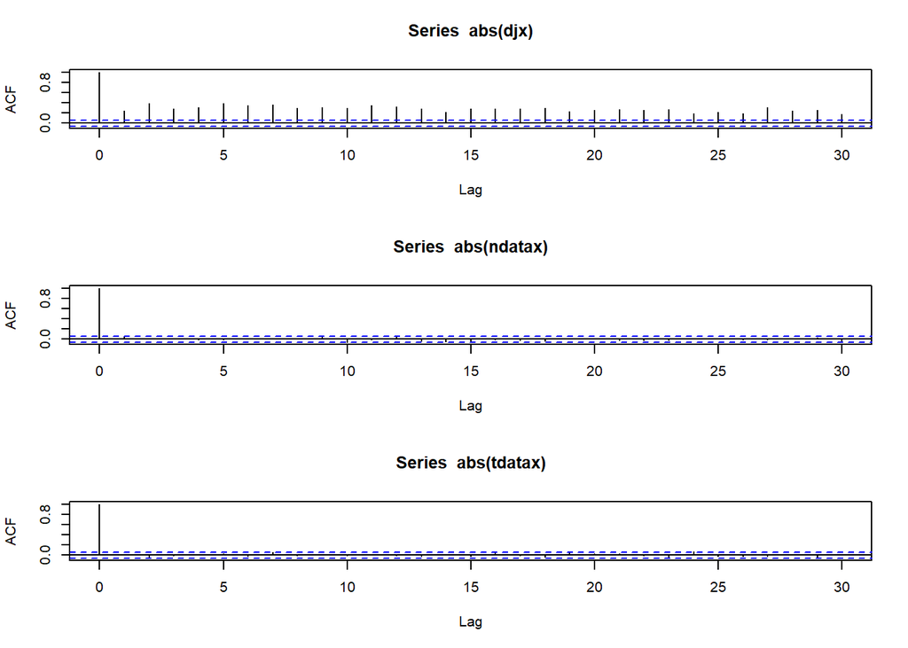

```r
# Plot the acfs of the absolute values
acf(abs(djx))
acf(abs(ndatax))
acf(abs(tdatax))
```